# Analysis: bodyfat prediction

#### 1.2.4.3 Summary of IDA

There seem to be some mismeasured data points in the following variables:

| Subject | Variable | Problem | Solution |
| --- | --- | --- | --- |
| 120 | Age | Age == 1 | set to NA |
| 42, 145 | Chest | Chest < 60 | set to NA |
| 31 | Calf | Calf == 66 | set to NA |
| 124 | Knee | Knee ==24.7 | set to NA |
| 136 | Elbow | Elbow == 15.5 | set to NA |

```r
# we first copy the data into an analysis set women_AS
women_AS <- women

# we now create NAs where data was implausible
women_AS$Age[women_AS$Age ==1] <- NA
women_AS$Chest[women_AS$Chest < 60] <- NA
women_AS$Calf[women_AS$Calf == 66] <- NA
women_AS$Knee[women_AS$Knee ==24.7] <-  NA
women_AS$Elbow[women_AS$Elbow == 15.5] <- NA
```

After this data cleaning, we repeat the IDA with the clean data. Since the missing values are not overlapping, we don’t have to pay special attention to their description.

```r
## transform
women_long_AS <-
  women_AS |>
  mutate(AgeP = Age) |>  ## Create a copy of AGE to store as a predictor
  pivot_longer(
    cols = c(-Obs,-Age,-Fat),
    names_to = "PARAMCD",
    values_to = "AVAL",
    values_drop_na = FALSE
  ) |>
  mutate(PARAMCD = if_else(PARAMCD == "AgeP", "Age", PARAMCD)) ## rename AGE param code
```

#### 1.2.4.4 IDA domain U: univariate descriptions

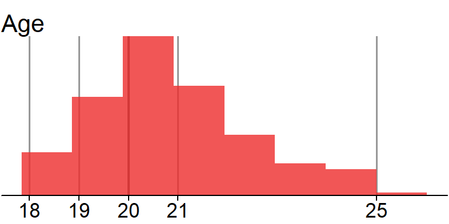

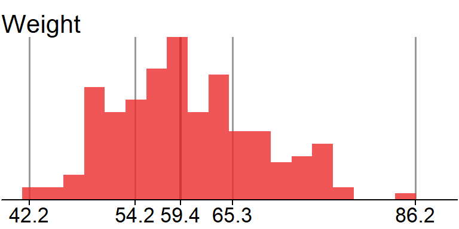

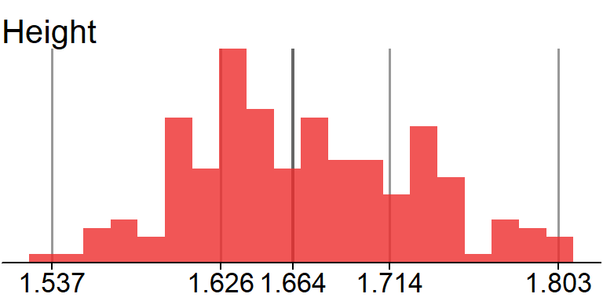

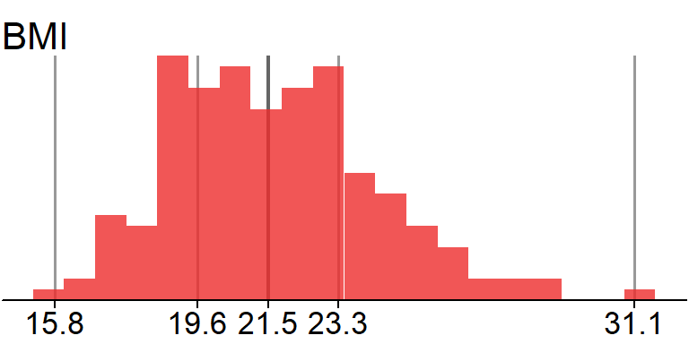

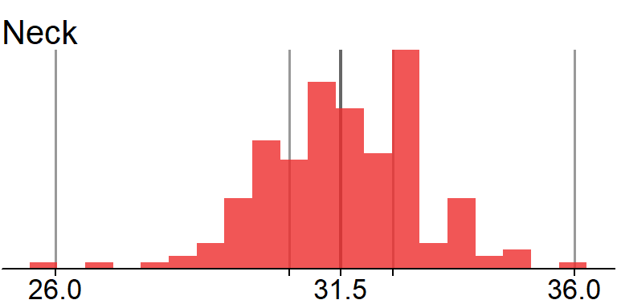

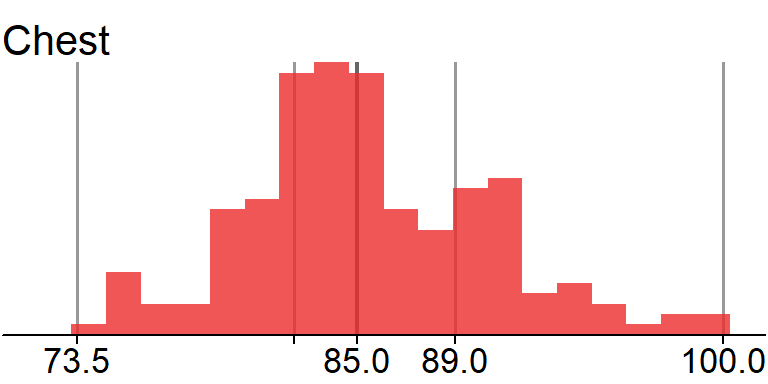

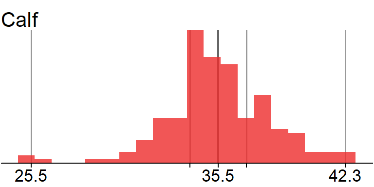

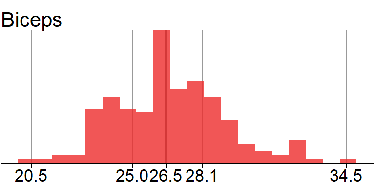

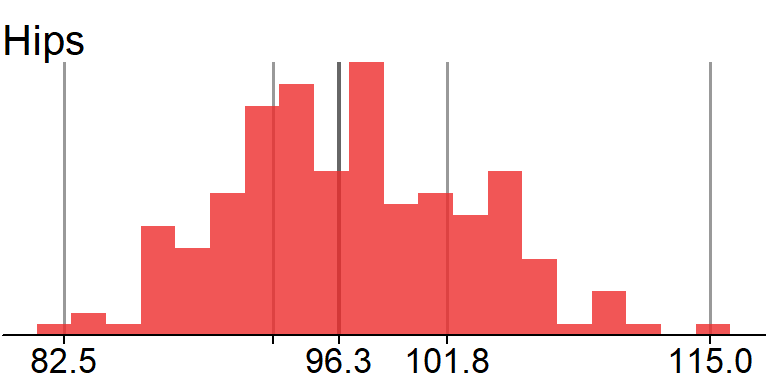

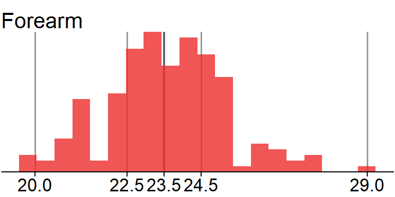

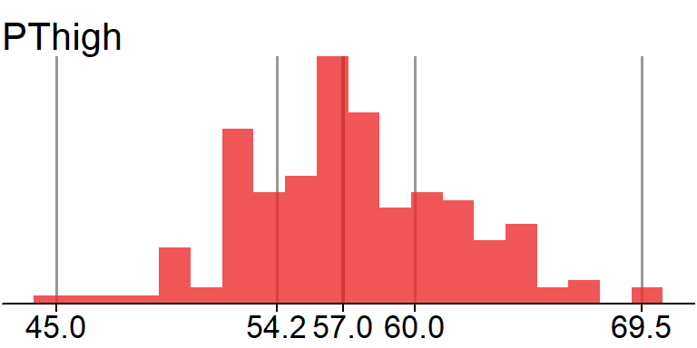

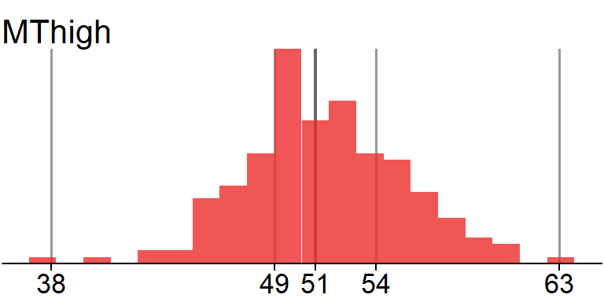

[5 more figures not shown]

#### IDA domain V: Correlation between predictors

Calculate correlation matrix using Spearman correlation coefficient.

The Spearman correlation coefficients are depicted in a quadratic heat map:

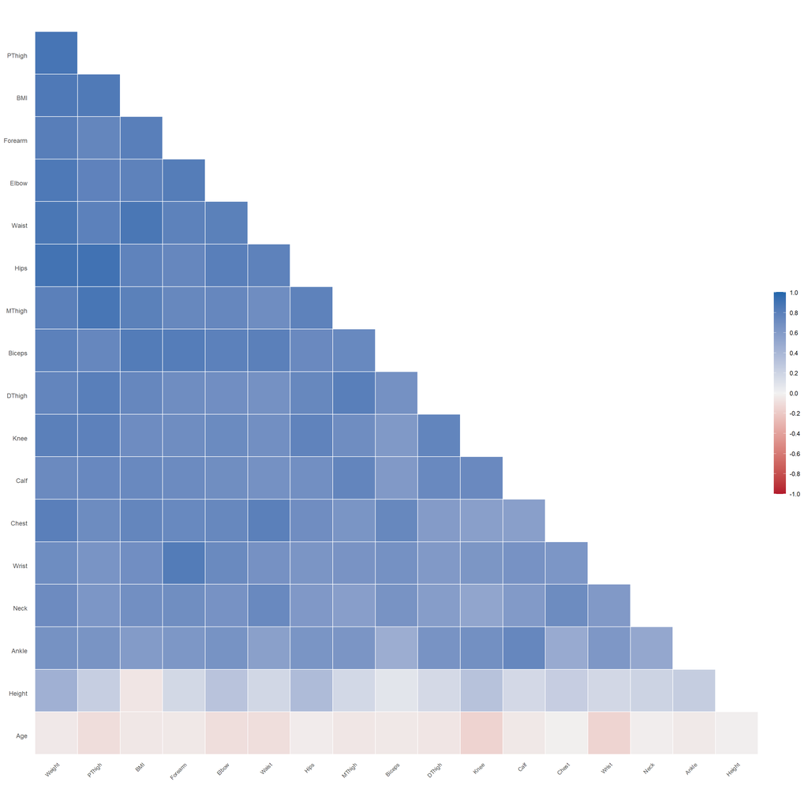

```r
corr_spearman_disp <- cbind(term=corr_spearman$term, round(corr_spearman[,-1]*100,0))
print(corr_spearman_disp)
```

```
      term Weight Height BMI Age Neck Chest Calf Biceps Hips Waist Forearm
1   Weight     NA     44  85  -4   71    80   72     79   90    87      81
2   Height     44     NA  -6  -1   20    24   17      8   37    18      17
3      BMI     85     -6  NA  -5   68    75   73     83   78    87      80
4      Age     -4     -1  -5  NA   -2    -1   -5     -5   -3    -9      -5
5     Neck     71     20  68  -2   NA    71   60     66   62    73      69
6    Chest     80     24  75  -1   71    NA   57     74   70    80      73
7     Calf     72     17  73  -5   60    57   NA     61   69    67      71
8   Biceps     79      8  83  -5   66    74   61     NA   73    80      82
9     Hips     90     37  78  -3   62    70   69     73   NA    78      74
10   Waist     87     18  87  -9   73    80   67     80   78    NA      79
11 Forearm     81     17  80  -5   69    73   71     82   74    79      NA
12  PThigh     88     24  84 -10   63    71   73     75   90    79      75
13  MThigh     79     17  79  -5   57    64   76     73   78    70      74
14  DThigh     76     16  74  -6   58    59   73     67   74    67      70
```

[output cut: 23 more lines]

### 1.2.5 Plot of the variables PThigh, MThigh, DThigh

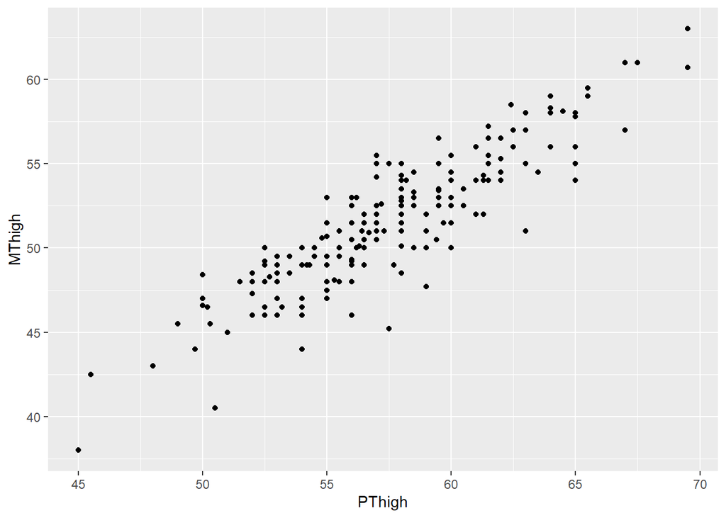

```r
ggplot(data=women_AS, aes(x=PThigh, y=MThigh)) + geom_point()
```

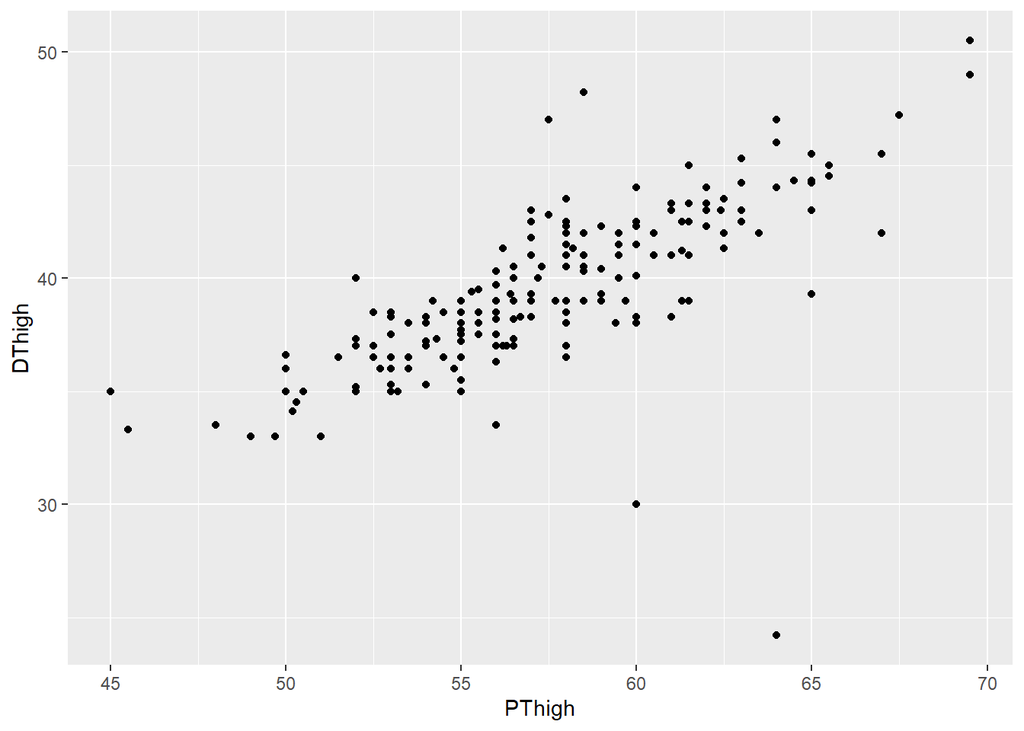

```r
ggplot(data=women_AS, aes(x=PThigh, y=DThigh)) + geom_point()
```

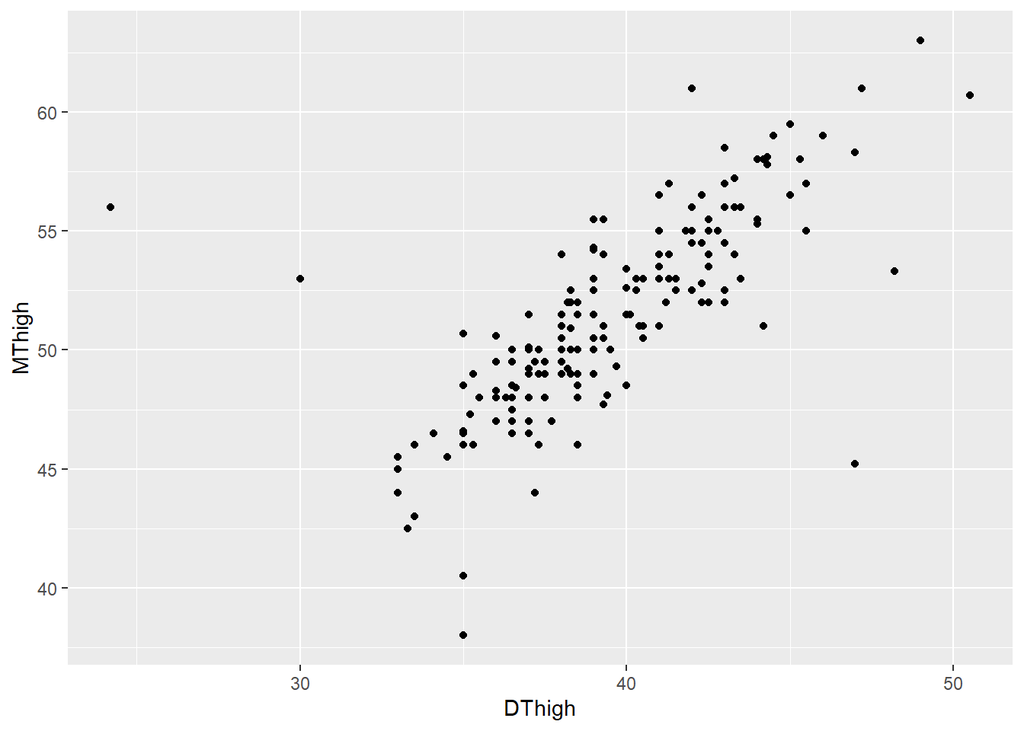

```r
ggplot(data=women_AS, aes(x=DThigh, y=MThigh)) + geom_point()
```

### 1.2.6 Summary from IDA

The key predictors Waist, Weight and Height have correlations of:

- Waist and Weight: 0.87
- Waist and Height: 0.18
- Weight and Height: 0.44

## 1.3 Main analysis

### 1.3.1 Model building

#### 1.3.1.1 Model M1

```r
library(mfp2)

x <- as.matrix(women_AS[, c("Waist", "Height", "Weight")])
y <- as.numeric(women_AS$Fat)

M1 <- mfp2(x=x, y=y, select=1, df=4, criterion="aic")
```

```
i Initial degrees of freedom:
   Waist Height Weight
df     4      4      4

i Visiting order: Weight, Height, Waist

---------------------
i Running MFP Cycle 1
---------------------

Variable: Weight (keep = FALSE)
                 Powers    DF    AIC
null             NA        4     1026.6
linear           1         5     1004.0
FP1              0.5       6     1005.8
FP2              3, 3      8     1009.2
Selected: linear

Variable: Height (keep = FALSE)
                 Powers    DF    AIC
null             NA        4     1023.2
linear           1         5     1004.0
FP1              3         6     1005.6
FP2              -2, -2    8     1009.0
Selected: linear

Variable: Waist (keep = FALSE)
                 Powers    DF    AIC
null             NA        4     1012.5
linear           1         5     1004.0
FP1              3         6     1005.3
FP2              -2, -2    8     1008.6
Selected: linear

---------------------
i Running MFP Cycle 2
---------------------

Variable: Weight (keep = FALSE)
                 Powers    DF    AIC
```

[output cut: 8 more lines]

```
null             NA        4     1023.2
linear           1         5     1004.0
FP1              3         6     1005.6
FP2              -2, -2    8     1009.0
Selected: linear

Variable: Waist (keep = FALSE)
                 Powers    DF    AIC
null             NA        4     1012.5
linear           1         5     1004.0
FP1              3         6     1005.3
FP2              -2, -2    8     1008.6
Selected: linear

i Fractional polynomial fitting algorithm converged after 2 cycles.
```

```r
summary(M1)
```

```
Call:
glm(formula = y ~ ., family = family, data = data, weights = weights,
    offset = offset, x = TRUE, y = TRUE)

Coefficients:
            Estimate Std. Error t value Pr(>|t|)
(Intercept)  21.7551     0.2687  80.970  < 2e-16 ***
Weight.1      3.8448     0.7577   5.074 9.63e-07 ***
Height.1    -26.3556     5.6319  -4.680 5.63e-06 ***
Waist.1       2.8788     0.8871   3.245   0.0014 **
---
Signif. codes:  0 '***' 0.001 '**' 0.01 '*' 0.05 '.' 0.1 ' ' 1

(Dispersion parameter for gaussian family taken to be 13.28297)

    Null deviance: 6182.4  on 183  degrees of freedom
Residual deviance: 2390.9  on 180  degrees of freedom
AIC: 1004

Number of Fisher Scoring iterations: 2
```

#### 1.3.1.2 Model M2

```r
x <- as.matrix(women_AS[, c("Waist", "Height", "Weight", "BMI")])
y <- as.numeric(women_AS$Fat)

M2 <- mfp2(x=x, y=y, df=c(4,4,4,2), criterion="aic", keep=c(T, T, T, F))
```

```
i Initial degrees of freedom:
   Waist Height Weight BMI
df     4      4      4   2

i Visiting order: Waist, BMI, Height, Weight

---------------------
i Running MFP Cycle 1
---------------------

Variable: Waist (keep = FALSE)
                 Powers    DF    AIC
null             NA        5     1012.7
linear           1         6     1004.4
FP1              3         7     1005.4
FP2              -2, -2    9     1008.2
Selected: linear

Variable: BMI (keep = FALSE)
                 Powers    DF    AIC
null             NA        5     1004.0
linear           1         6     1004.4
FP1              2         7     1006.9
Selected: null

Variable: Height (keep = FALSE)
                 Powers    DF    AIC
null             NA        4     1023.2
linear           1         5     1004.0
FP1              3         6     1005.6
FP2              -2, -2    8     1009.0
Selected: linear

Variable: Weight (keep = FALSE)
                 Powers    DF    AIC
null             NA        4     1026.6
linear           1         5     1004.0
FP1              0.5       6     1005.8
FP2              3, 3      8     1009.2
Selected: linear
```

[output cut: 22 more lines]

```
null             NA        4     1023.2
linear           1         5     1004.0
FP1              3         6     1005.6
FP2              -2, -2    8     1009.0
Selected: linear

Variable: Weight (keep = FALSE)
                 Powers    DF    AIC
null             NA        4     1026.6
linear           1         5     1004.0
FP1              0.5       6     1005.8
FP2              3, 3      8     1009.2
Selected: linear

i Fractional polynomial fitting algorithm converged after 2 cycles.
```

```r
summary(M2)
```

```
Call:
glm(formula = y ~ ., family = family, data = data, weights = weights,
    offset = offset, x = TRUE, y = TRUE)

Coefficients:
            Estimate Std. Error t value Pr(>|t|)
(Intercept)  21.7551     0.2687  80.970  < 2e-16 ***
Waist.1       2.8788     0.8871   3.245   0.0014 **
Height.1    -26.3556     5.6319  -4.680 5.63e-06 ***
Weight.1      3.8448     0.7577   5.074 9.63e-07 ***
---
Signif. codes:  0 '***' 0.001 '**' 0.01 '*' 0.05 '.' 0.1 ' ' 1

(Dispersion parameter for gaussian family taken to be 13.28297)

    Null deviance: 6182.4  on 183  degrees of freedom
Residual deviance: 2390.9  on 180  degrees of freedom
AIC: 1004

Number of Fisher Scoring iterations: 2
```

#### 1.3.1.3 Model M3

```r
# refit M2
women_AS_nona <- women_AS[complete.cases(women_AS),]

# instead of forward, use backward but keep Waist, Height and Weight from exclusion

xM3 <- as.matrix(women_AS_nona[,-c(1,2,5)])
yM3 <- women_AS_nona[,2]

M3 <- mfp2(y=yM3, x=xM3, keep=c("Height","Weight","Waist"), df=c(4, 4, 2, 2, 2, 2, 2, 2, 4, 2, 2, 2, 2, 2, 2, 2, 2))
```

```
i Initial degrees of freedom:
   Weight Height Age Neck Chest Calf Biceps Hips Waist Forearm PThigh MThigh
df      4      4   2    2     2    2      2    2     4       2      2      2
   DThigh Wrist Knee Elbow Ankle
df      2     2    2     2     2

i Visiting order: Height, Waist, Knee, Hips, Weight, Biceps, Wrist, Ankle, Elbow, Chest, Calf, Age, Forearm, PThigh, Neck, MThigh, DThigh

---------------------
i Running MFP Cycle 1
---------------------

Variable: Height (keep = TRUE)
                 Powers    DF    Deviance    Versus           Deviance diff.
FP2              -2, -2    22    933.3       .                .
null             NA        18    945.1       FP2              11.8
linear           1         19    933.5       FP2              0.2
                 P-value
FP2              .
null             0.0188
linear           0.9810
Selected: linear

Variable: Waist (keep = TRUE)
                 Powers    DF    Deviance    Versus           Deviance diff.
FP2              -2, -2    22    933.2       .                .
null             NA        18    943.5       FP2              10.3
linear           1         19    933.5       FP2              0.3
                 P-value
FP2              .
null             0.0359
linear           0.9583
Selected: linear

Variable: Knee (keep = FALSE)
                 Powers    DF    Deviance    Versus           Deviance diff.
FP1              -2        20    932.6       .                .
null             NA        18    939.8       FP1              7.2
linear           1         19    933.5       FP1              0.9
                 P-value
```

[output cut: 626 more lines]

```
                 P-value
FP1              .
null             0.9241
Selected: null

Variable: DThigh (keep = FALSE)
                 Powers    DF    Deviance    Versus           Deviance diff.
FP1              -2        10    941.6       .                .
null             NA        8     941.7       FP1              0.1
                 P-value
FP1              .
null             0.9493
Selected: null

i Fractional polynomial fitting algorithm converged after 4 cycles.
```

```r
summary(M3)
```

```
Call:
glm(formula = y ~ ., family = family, data = data, weights = weights,
    offset = offset, x = TRUE, y = TRUE)

Coefficients:
            Estimate Std. Error t value Pr(>|t|)
(Intercept)  21.8301     0.2561  85.240  < 2e-16 ***
Height.1    -26.2742     5.6948  -4.614  7.7e-06 ***
Waist.1       3.1485     0.8477   3.714 0.000275 ***
Knee.1        4.7025     2.0024   2.348 0.019989 *
Hips.1        2.5695     0.9412   2.730 0.006994 **
Weight.1      1.9816     1.0609   1.868 0.063485 .
Wrist.1      -1.1571     0.4191  -2.761 0.006396 **
---
Signif. codes:  0 '***' 0.001 '**' 0.01 '*' 0.05 '.' 0.1 ' ' 1

(Dispersion parameter for gaussian family taken to be 11.74027)

    Null deviance: 6107.7  on 178  degrees of freedom
Residual deviance: 2019.3  on 172  degrees of freedom
AIC: 957.72

Number of Fisher Scoring iterations: 2
```

#### 1.3.1.4 Model M4

```r
# refit M3 with complete cases

women_AS_M3 <- women_AS[complete.cases(women_AS[,c("Height","Waist","Knee","Hips","Weight","Wrist")]),]

xM3r <- as.matrix(women_AS_M3[,c("Height","Waist","Knee","Hips","Weight","Wrist")])
yM3r <- women_AS_M3[,"Fat"]
M3.refit <- mfp2(y=yM3r, x=xM3r, keep=c("Height","Waist","Knee","Hips","Weight","Wrist"), df=c(4, 4, 2, 2, 4, 2))
```

```
i Initial degrees of freedom:
   Height Waist Knee Hips Weight Wrist
df      4     4    2    2      4     2

i Visiting order: Height, Waist, Hips, Wrist, Knee, Weight

---------------------
i Running MFP Cycle 1
---------------------

Variable: Height (keep = TRUE)
                 Powers    DF    Deviance    Versus           Deviance diff.
FP2              -2, -2    11    963.1       .                .
null             NA        7     986.0       FP2              22.9
linear           1         8     964.2       FP2              1.1
                 P-value
FP2              .
null             0.0001
linear           0.7768
Selected: linear

Variable: Waist (keep = TRUE)
                 Powers    DF    Deviance    Versus           Deviance diff.
FP2              -2, -2    11    963.1       .                .
null             NA        7     977.6       FP2              14.5
linear           1         8     964.2       FP2              1.1
                 P-value
FP2              .
null             0.0060
linear           0.7867
Selected: linear

Variable: Hips (keep = TRUE)
                 Powers    DF    Deviance    Versus           Deviance diff.
FP1              -2        9     962.5       .                .
null             NA        7     972.8       FP1              10.3
linear           1         8     964.2       FP1              1.6
                 P-value
FP1              .
null             0.0058
```

[output cut: 92 more lines]

```
linear           0.3978
Selected: linear

Variable: Weight (keep = TRUE)
                 Powers    DF    Deviance    Versus           Deviance diff.
FP2              -2, -1    11    964.1       .                .
null             NA        7     967.1       FP2              3.0
linear           1         8     964.2       FP2              0.1
                 P-value
FP2              .
null             0.5499
linear           0.9956
Selected: linear

i Fractional polynomial fitting algorithm converged after 2 cycles.
```

```r
summary(M3.refit)
```

```
Call:
glm(formula = y ~ ., family = family, data = data, weights = weights,
    offset = offset, x = TRUE, y = TRUE)

Coefficients:
            Estimate Std. Error t value Pr(>|t|)
(Intercept)  21.7873     0.2541  85.727  < 2e-16 ***
Height.1    -26.2786     5.5693  -4.718 4.82e-06 ***
Waist.1       3.0877     0.8446   3.656 0.000338 ***
Hips.1        2.7401     0.9391   2.918 0.003986 **
Wrist.1      -1.0090     0.4125  -2.446 0.015437 *
Knee.1        4.4621     1.9969   2.235 0.026703 *
Weight.1      1.7982     1.0577   1.700 0.090872 .
---
Signif. codes:  0 '***' 0.001 '**' 0.01 '*' 0.05 '.' 0.1 ' ' 1

(Dispersion parameter for gaussian family taken to be 11.81999)

    Null deviance: 6147.4  on 182  degrees of freedom
Residual deviance: 2080.3  on 176  degrees of freedom
AIC: 980.17

Number of Fisher Scoring iterations: 2
```

```r
M4.fp1 <- mfp2(y=yM3r, x=xM3r, keep=NULL, select=0.084, df=c(2, 2, 2, 2, 2, 2), cycles=1)
```

```
i Initial degrees of freedom:
   Height Waist Knee Hips Weight Wrist
df      2     2    2    2      2     2

i Visiting order: Height, Waist, Hips, Wrist, Knee, Weight

---------------------
i Running MFP Cycle 1
---------------------

Variable: Height (keep = FALSE)
                 Powers    DF    Deviance    Versus           Deviance diff.
FP1              3         9     963.7       .                .
null             NA        7     986.0       FP1              22.2
linear           1         8     964.2       FP1              0.4
                 P-value
FP1              .
null             0.0000
linear           0.5078
Selected: linear

Variable: Waist (keep = FALSE)
                 Powers    DF    Deviance    Versus           Deviance diff.
FP1              2         9     963.6       .                .
null             NA        7     977.6       FP1              13.9
linear           1         8     964.2       FP1              0.5
                 P-value
FP1              .
null             0.0010
linear           0.4711
Selected: linear

Variable: Hips (keep = FALSE)
                 Powers    DF    Deviance    Versus           Deviance diff.
FP1              -2        9     962.5       .                .
null             NA        7     972.8       FP1              10.3
linear           1         8     964.2       FP1              1.6
                 P-value
FP1              .
null             0.0058
```

[output cut: 18 more lines]

```
linear           1         8     964.2       FP1              0.7
                 P-value
FP1              .
null             0.0541
linear           0.3978
Selected: linear

Variable: Weight (keep = FALSE)
                 Powers    DF    Deviance    Versus           Deviance diff.
FP1              0.5       9     964.1       .                .
null             NA        7     967.1       FP1              3.0
                 P-value
FP1              .
null             0.2201
Selected: null
```

```r
summary(M4.fp1)
```

```
Call:
glm(formula = y ~ ., family = family, data = data, weights = weights,
    offset = offset, x = TRUE, y = TRUE)

Coefficients:
            Estimate Std. Error t value Pr(>|t|)
(Intercept)  21.7873     0.2555  85.273  < 2e-16 ***
Height.1    -21.1596     4.7101  -4.492 1.27e-05 ***
Waist.1       3.9643     0.6725   5.895 1.86e-08 ***
Hips.1        3.5663     0.8079   4.414 1.76e-05 ***
Wrist.1      -0.7475     0.3848  -1.942  0.05367 .
Knee.1        5.1578     1.9649   2.625  0.00942 **
---
Signif. codes:  0 '***' 0.001 '**' 0.01 '*' 0.05 '.' 0.1 ' ' 1

(Dispersion parameter for gaussian family taken to be 11.94624)

    Null deviance: 6147.4  on 182  degrees of freedom
Residual deviance: 2114.5  on 177  degrees of freedom
AIC: 981.15

Number of Fisher Scoring iterations: 2
```

```r
sel.predictors.M4.fp1 <- rownames(M4.fp1$fp_terms[M4.fp1$fp_terms[,"selected"],])

M4.lin <- mfp2(y=yM3r, x=xM3r, keep=NULL, select=0.084, df=c(1, 1, 1, 1, 1, 1), cycles=1)
```

```
i Initial degrees of freedom:
   Height Waist Knee Hips Weight Wrist
df      1     1    1    1      1     1

i Visiting order: Height, Waist, Hips, Wrist, Knee, Weight

---------------------
i Running MFP Cycle 1
---------------------

Variable: Height (keep = FALSE)
                 Powers    DF    Deviance    Versus           Deviance diff.
null             NA        7     986.0       .                .
linear           1         8     964.2       null             21.8
                 P-value
null             .
linear           0.0000
Selected: linear

Variable: Waist (keep = FALSE)
                 Powers    DF    Deviance    Versus           Deviance diff.
null             NA        7     977.6       .                .
linear           1         8     964.2       null             13.4
                 P-value
null             .
linear           0.0003
Selected: linear

Variable: Hips (keep = FALSE)
                 Powers    DF    Deviance    Versus           Deviance diff.
null             NA        7     972.8       .                .
linear           1         8     964.2       null             8.6
                 P-value
null             .
linear           0.0033
Selected: linear

Variable: Wrist (keep = FALSE)
                 Powers    DF    Deviance    Versus           Deviance diff.
null             NA        7     970.3       .                .
```

[output cut: 8 more lines]

```
null             NA        7     969.3       .                .
linear           1         8     964.2       null             5.1
                 P-value
null             .
linear           0.0237
Selected: linear

Variable: Weight (keep = FALSE)
                 Powers    DF    Deviance    Versus           Deviance diff.
null             NA        7     967.1       .                .
linear           1         8     964.2       null             3.0
                 P-value
null             .
linear           0.0842
Selected: null
```

```r
summary(M4.lin)
```

```
Call:
glm(formula = y ~ ., family = family, data = data, weights = weights,
    offset = offset, x = TRUE, y = TRUE)

Coefficients:
            Estimate Std. Error t value Pr(>|t|)
(Intercept)  21.7873     0.2555  85.273  < 2e-16 ***
Height.1    -21.1596     4.7101  -4.492 1.27e-05 ***
Waist.1       3.9643     0.6725   5.895 1.86e-08 ***
Hips.1        3.5663     0.8079   4.414 1.76e-05 ***
Wrist.1      -0.7475     0.3848  -1.942  0.05367 .
Knee.1        5.1578     1.9649   2.625  0.00942 **
---
Signif. codes:  0 '***' 0.001 '**' 0.01 '*' 0.05 '.' 0.1 ' ' 1

(Dispersion parameter for gaussian family taken to be 11.94624)

    Null deviance: 6147.4  on 182  degrees of freedom
Residual deviance: 2114.5  on 177  degrees of freedom
AIC: 981.15

Number of Fisher Scoring iterations: 2
```

### 1.3.2 SAP amendments

#### 1.3.2.1 Problems encountered and solutions

- Forward selection not possible with mfp2
- Because forward selection is not possible with the `mfp2` package, we the MFP algorithm is performed using M2 as starting model, and using all remaining predictors in the scope to obtain M3.
- M3 selected 6 variables which had to be reduced to 5 for M4. In M3 there were only linear effects involved. Since `mfp2` does not allow to select a fixed number of predictors out of a larger set of candidate predictors, we tuned the significance level for selection in `mfp2` in order to yield exactly 5 predictors. We accepted that it might not always be possible to find a significance level that yields 5 predictors.
- At external validation, in addition to calculating all performance measures, the prediction error, calibration slope and R-squared was also computed after correcting for miscalibration-in-the-large.

### 1.3.3 Model diagnostics

#### 1.3.3.1 Check local bias

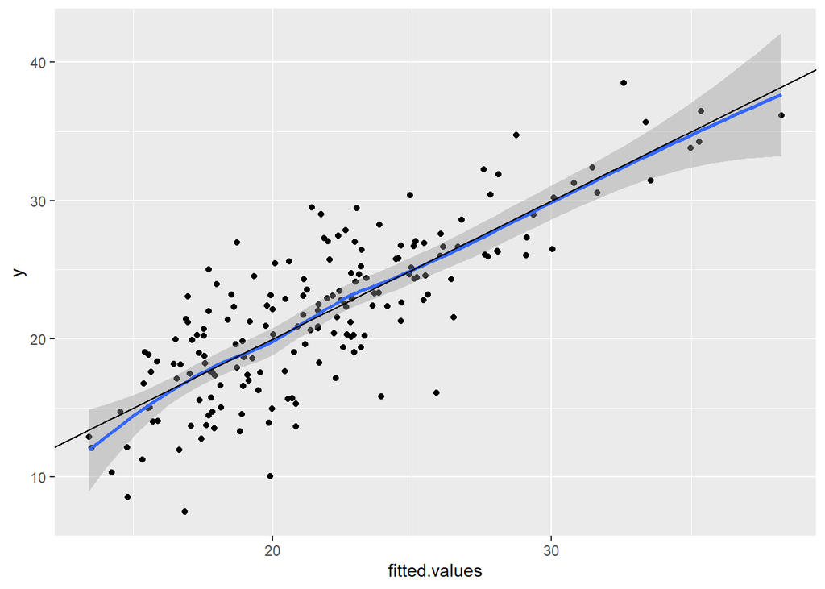

```r
ggplot(data.frame(fitted.values=M4.fp1$fitted.values, y=M4.fp1$y), aes(x=fitted.values, y=y)) + geom_point() + geom_smooth() + geom_abline(slope=1, intercept=0)
```

Observation: There seems to be only little local bias at the very lower end of the distribution of fitted values.

#### 1.3.3.2 Check heteroskedasticity

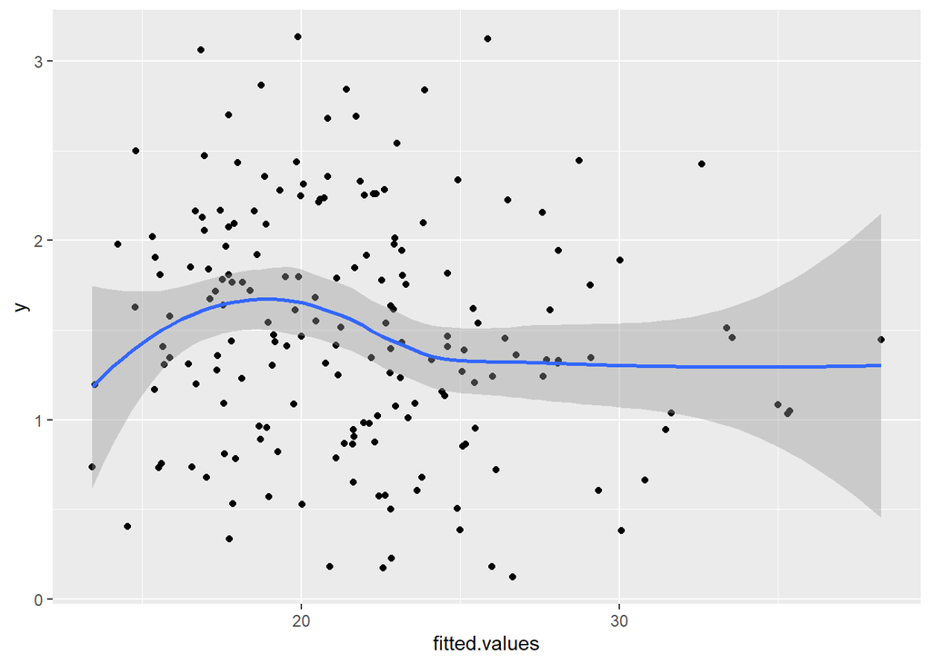

```r
ggplot(data.frame(fitted.values=M4.fp1$fitted.values, y=sqrt(abs(M4.fp1$residuals))), aes(x=fitted.values, y=y)) + geom_point() + geom_smooth()
```

#### 1.3.3.3 Check association with excluded predictors

The MFP algorithm iteratively checks for possible inclusion of previously excluded predictors. Hence, we do not expect that any predictor might show an relevant association with the model residuals. Still, we will check this for Weight, which was excluded when moving from M3 to M4.

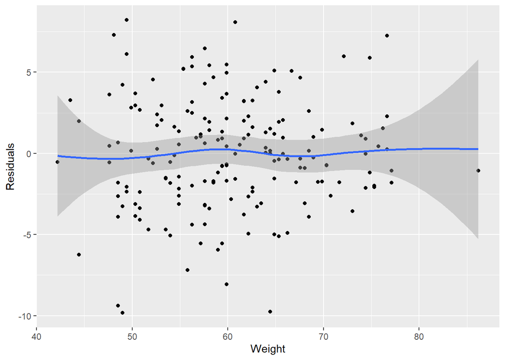

```r
ggplot(data.frame(Weight=women_AS_M3$Weight, Residuals=M4.fp1$residuals), aes(x=Weight, y=Residuals)) + geom_point() + geom_smooth()
```

Observation: No residual association with Weight can be noted.

#### 1.3.3.4 Check normality of residuals

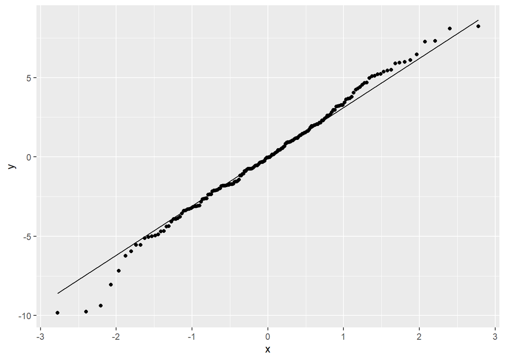

```r
ggplot(data.frame(residuals=M4.fp1$residuals), aes(sample=residuals)) +
  stat_qq(distribution = qnorm) +
  stat_qq_line(distribution = qnorm)
```

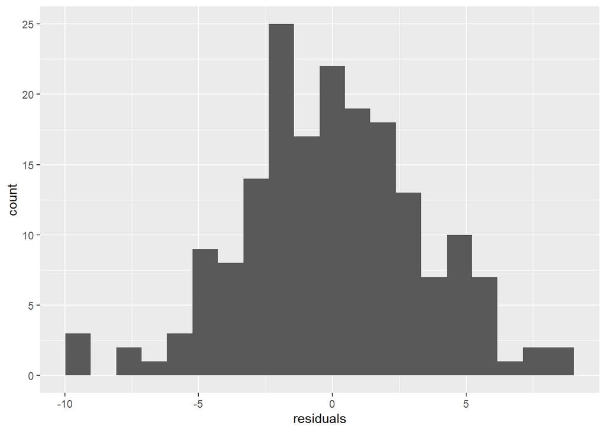

```r
ggplot(data=data.frame(residuals=M4.fp1$residuals), aes(x=residuals)) + geom_histogram(bins=20)
```

Conclusion: there are only little deviations from the normality assumption for residuals, probably more on the left tail.

### 1.3.4 Apparent performance of the model

#### 1.3.4.1 Root mean squared prediction error

```r
rmspe_app <- sqrt(mean(M4.fp1$residuals^2))
rmspe_app
```

```
[1] 3.3992
```

#### 1.3.4.2 Adjusted R-square

```r
model_df = length(coef(M4.fp1))
n = dim(women_AS_M3)[1]

R2_adj_app <- 1-(sum(M4.fp1$residuals^2)/(n-model_df)) / var(women_AS_M3$Fat)
R2_adj_app
```

```
[1] 0.6463202
```

### 1.3.5 Model description

#### 1.3.5.1 Term plots

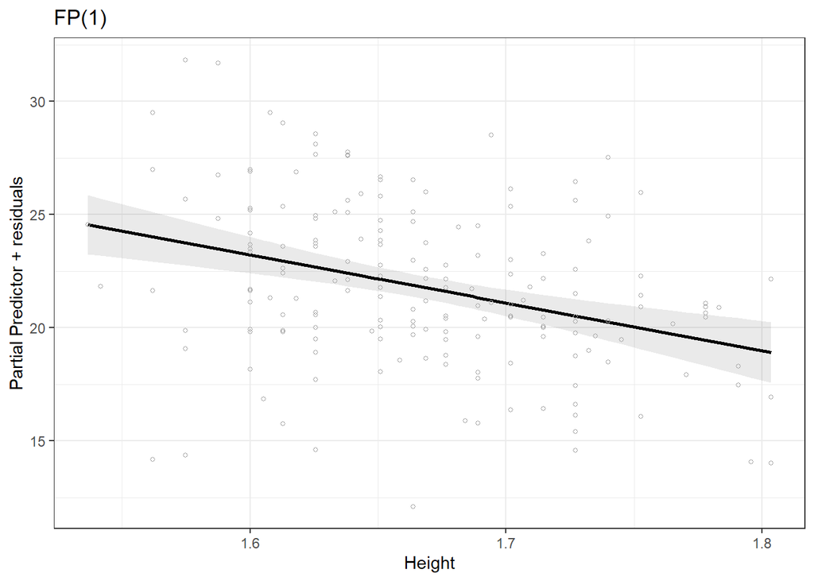

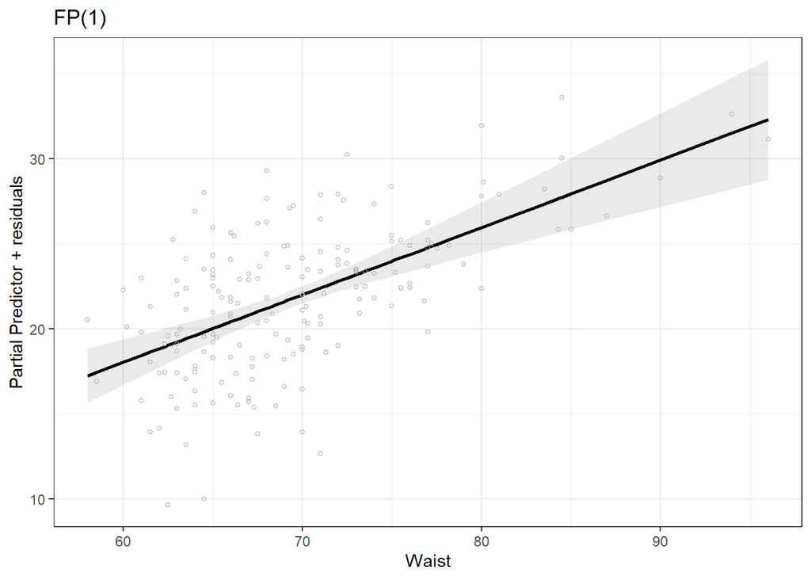

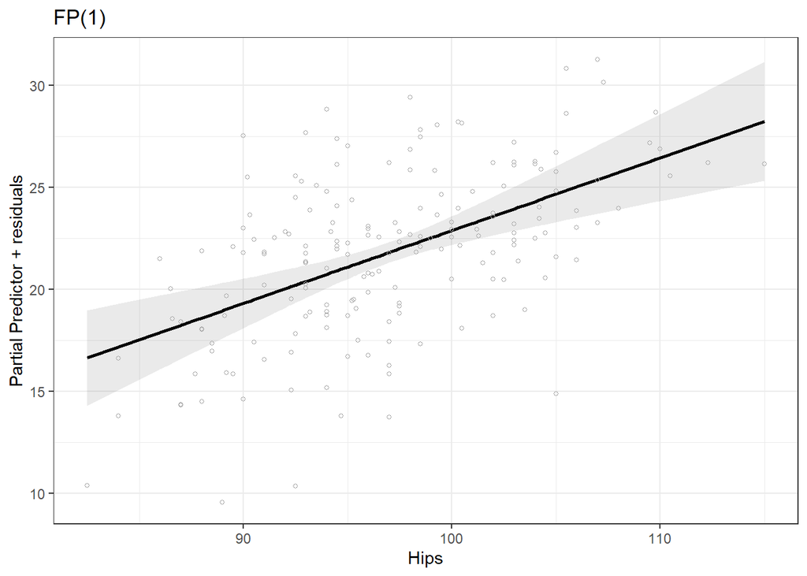

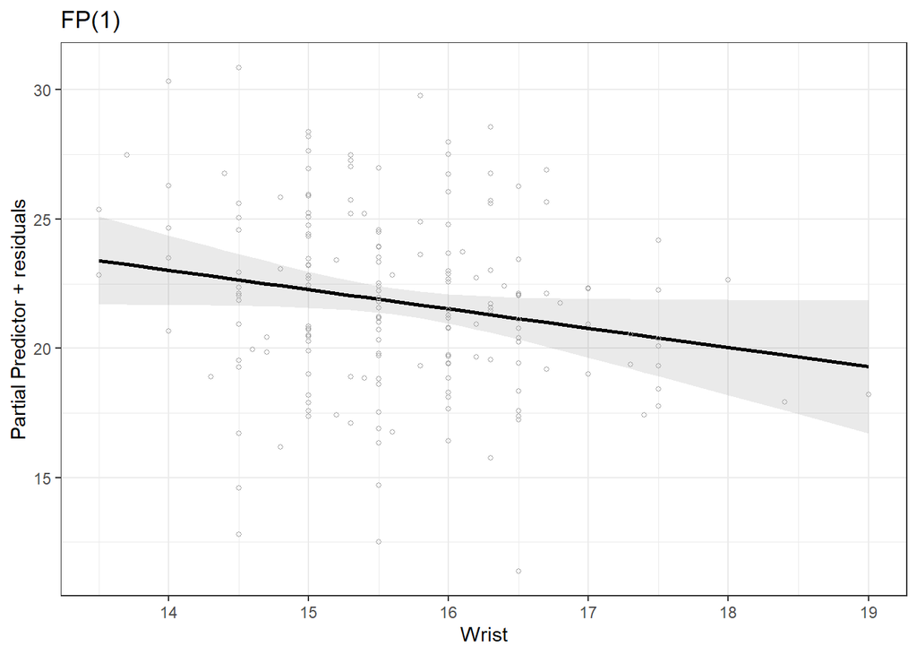

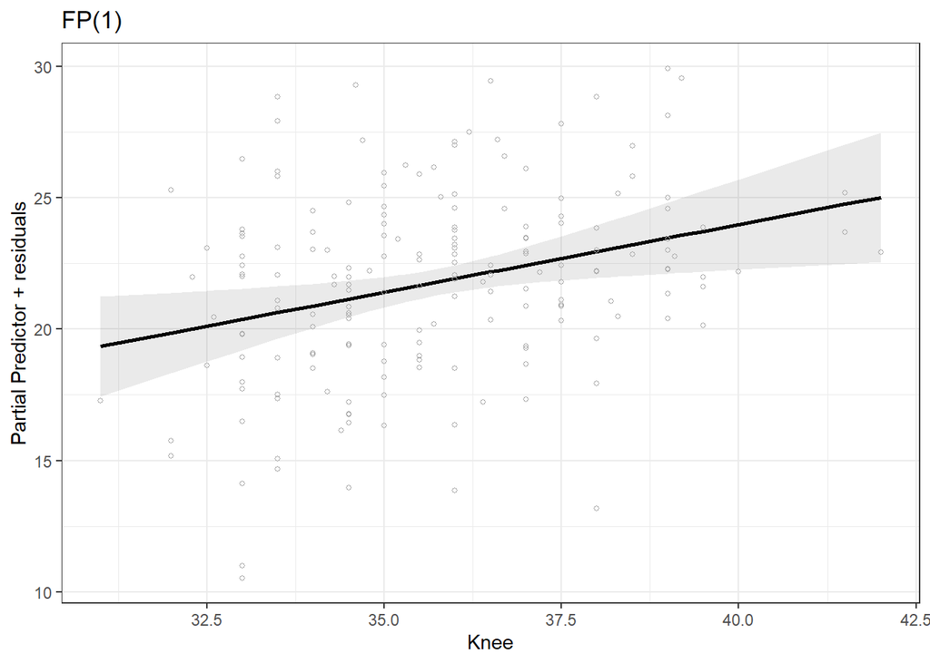

```r
fracplot(M4.fp1)
```

#### 1.3.5.2 Standardized regression coefficients

```r
sd.beta <- coef(M4.fp1) * apply(M4.fp1$x, 2, sd)
sd.beta
```

```
(Intercept)    Height.1     Waist.1      Hips.1     Wrist.1      Knee.1
  0.0000000  -1.2462894   2.5552066   2.1872500  -0.7022766   1.1189321
```

# 2 Internal validation

## 2.1 Performing bootstrap replications of model building

```r
# define a function that automates the complex model building process. The function returns the model M4.
model_build <- function(data, verbose=FALSE){
  x <- as.matrix(data[, c("Waist", "Height", "Weight")])
  y <- as.numeric(data$Fat)
  M1 <- mfp2(x=x, y=y, select=1, df=4, criterion="aic", verbose=verbose)
  x <- as.matrix(data[, c("Waist", "Height", "Weight", "BMI")])
  y <- as.numeric(data$Fat)

  M2 <- mfp2(x=x, y=y, df=c(4,4,4,2), criterion="pvalue", select=0.157, alpha=0.157, keep=c("Waist", "Height", "Weight"), verbose=verbose)

  data_nona <- data[complete.cases(data),]

  # instead of forward, use backward but keep Waist, Height and Weight from exclusion

  yM3 <- data_nona[,2]

  if(M2$fp_terms["BMI","selected"]){
    xM3 <- as.matrix(data_nona[,-c(1,2)])
    keep <- c("Height","Weight","BMI","Waist")
    df <-  c(4, 4, 2, 2, 2, 2, 2, 2, 2, 4, 2, 2, 2, 2, 2, 2, 2, 2)
  } else {
    xM3 <- as.matrix(data_nona[,-c(1,2,5)])
    keep <- c("Height","Weight","Waist")
    df <-  c(4, 4, 2, 2, 2, 2, 2, 2, 4, 2, 2, 2, 2, 2, 2, 2, 2)
  }

  M3 <- mfp2(y=yM3, x=xM3,
             keep=keep,
             df=df,
             order="descending", criterion="pvalue", select=0.5, alpha=0.157, verbose=verbose)
  sel_predictors <- rownames(M3$fp_terms[M3$fp_terms[,"selected"],])
  if(length(sel_predictors)<=5){
    M4 <- M3
  } else {
    data_M4 <- data[,c("Fat", sel_predictors)]
    data_M4 <- data_M4[complete.cases(data_M4),]
    xM4 <- as.matrix(data_M4[,sel_predictors])
    yM4 <- data_M4[,"Fat"]

    # perform as many iterations as needed to have only 5 terms in the model. set the alpha to 0.157 to approximate aic for functional form selection. one has to play with the select argument to get exactly 5 predictors. This is done using uniroot() with (N_selected - 5) as target function of parameter select to be minimized.

    f <- function(sel){
      fit <-mfp2(x=xM4, y=yM4, df = ifelse(sel_predictors %in% c("Waist", "Weight", "Height"), 4, 2), select=sel, alpha=0.157, verbose=FALSE, order="descending")
      ret <- sum(fit$fp_terms[,"selected"]) - 5
      return(ret)
    }
    opt_res <- uniroot(f, interval=c(0.0000001, 1),tol=0.001)
    M4 <- mfp2(x=xM4, y=yM4, select=opt_res$root, alpha=0.157, df= ifelse(sel_predictors %in% c("Waist", "Weight", "Height"), 4, 2), order="descending", verbose=verbose)
  }
  return(M4)
}

# ranges for selected predictors (100 equidistant steps)

pred_range <- data.frame(
  Waist = seq(min(women_AS$Waist), max(women_AS$Waist), diff(range(women_AS$Waist))/99),
  Height = seq(min(women_AS$Height), max(women_AS$Height), diff(range(women_AS$Height))/99),
  Hips = seq(min(women_AS$Hips), max(women_AS$Hips), diff(range(women_AS$Hips))/99),
  Wrist = seq(min(women_AS$Wrist), max(women_AS$Wrist), diff(range(women_AS$Wrist))/99),
  Knee = seq(min(women_AS$Knee, na.rm=T), max(women_AS$Knee, na.rm=T), diff(range(women_AS$Knee, na.rm=T))/99))
# could be automated with sel.predictors.M4.fp1

p.M4.fp1 <- predict(M4.fp1, newdata=pred_range, type="terms", terms=c("Waist", "Height", "Hips", "Wrist", "Knee"))

  candidate_predictors <- colnames(women_AS)[-c(1,2)]
  ncp <- length(candidate_predictors)
  N <- nrow(women_AS)


do_bootstrap <- FALSE

B <- 1000

if(do_bootstrap){
  # run the bootstrap. We need to save the sigma_b_test and sigma_b_app, and rsqu_b_test and rsqu_b_app; as well as the selection pattern and the predicted terms per variable.

  sigma_b_test <- sigma_b_app <- rsqu_b_test <- rsqu_b_app <- calib_slope <- (1:1000)*0
  sel_frequency <- matrix(0, B, ncp)
  power1_sel <- power2_sel <- matrix(NA, B, ncp)
  colnames(sel_frequency) <- colnames(power1_sel) <- colnames(power2_sel) <- candidate_predictors


  spagh.mat <- matrix(mean(M4.fp1$y), 100, B)

  spagh <- lapply(sel.predictors.M4.fp1, function(X) spagh.mat)
  names(spagh) <- sel.predictors.M4.fp1

  set.seed(7123981)


  for(b in 1:B){
    idB <- sample(1:N, repl=TRUE)
    id_oob <- is.na(match(1:N, idB))
    data_train <- women_AS[idB,]
    data_test <- women_AS[id_oob,]
    BM4 <- model_build(data_train)

    # remove missing values with respect to predictors from data_train and data_test
    sel_predictors <- rownames(BM4$fp_terms)[BM4$fp_terms[,"selected"]]
    data_train <- data_train[complete.cases(data_train[,sel_predictors]),c(sel_predictors,"Fat")]
    data_test <- data_test[complete.cases(data_test[,sel_predictors]),c(sel_predictors,"Fat")]

    pred_train <- predict(BM4, data_train)
    res_train <- data_train$Fat - pred_train
    df_BM4 <- sum(BM4$fp_terms[,"df_final"])
    n_BM4 <- nrow(data_train)

    pred_test <- predict(BM4, data_test)
    res_test <- data_test$Fat - pred_test

    sigma_b_app[b] <- sqrt(sum(res_train^2)/(n_BM4-df_BM4-1))
    sigma_b_test[b] <- sqrt(mean(res_test^2))

    rsqu_b_app[b] <- 1 - sigma_b_app[b]^2 / var(data_train$Fat)
    rsqu_b_test[b] <- 1 - sigma_b_test[b]^2 / var(data_test$Fat)  ### alternative formulation: MSE relative to mean of training set)

    # calibration slope

    calib_slope[b] <- coef(lm(data_test$Fat ~ pred_test))[2]

    # predictor selection frequency

    sel_frequency[b, sel_predictors] <- 1

    # functional form selection frequency

      power1_sel[b, sel_predictors] <- BM4$fp_terms[sel_predictors, "power1"]
    if(any(BM4$fp_terms[,"df_final"]>2)) power2_sel[b, sel_predictors] <- BM4$fp_terms[sel_predictors, "power2"]


    # contributions to spaghetti plots (for selected predictors)
    b.BM4 <- predict(BM4, newdata=pred_range, type="terms", terms=c("Waist", "Height", "Hips", "Wrist", "Knee"))
    for(p in sel.predictors.M4.fp1) {
      if(!is.null(b.BM4[[p]])) spagh[[p]][,b] <- b.BM4[[p]][,"value"]
      else spagh[[p]][,b] <- mean(BM4$y)    # mean Fat in bootstrap sample (which would be predicted for all)
    }

  }

  save(list=c("spagh", "sel_frequency", "power1_sel", "power2_sel", "calib_slope", "sigma_b_app", "sigma_b_test", "rsqu_b_app", "rsqu_b_test"), file="spagh.Rdata")

} else {
  load("spagh.Rdata")
}


rmspe_optcorr <- rmspe_app - mean(sigma_b_app - sigma_b_test)
rsqu_optcorr <- R2_adj_app - mean(rsqu_b_app - rsqu_b_test)
rmspe_optcorr_ci <- rmspe_app - quantile(sigma_b_app - sigma_b_test, c(0.975, 0.025))
rsqu_optcorr_ci <- R2_adj_app - quantile(rsqu_b_app - rsqu_b_test, c(0.975, 0.025))

mean_calib_slope <- mean(calib_slope)
calib_slope_ci <- quantile(calib_slope, c(0.025, 0.975))

predictor_sf <- apply(sel_frequency, 2, mean)
powers_sel <- matrix(paste(power1_sel, power2_sel), B, ncp, byrow=FALSE)
colnames(powers_sel) <- candidate_predictors
powers_sf <- lapply(candidate_predictors, function(X) {
  res<-t(t(-sort(-table(powers_sel[,X]))))/B
  colnames(res) <- "prop_selected"
  res
})
names(powers_sf) <- candidate_predictors
```

## 2.2 Optimism-corrected measures of performance

### 2.2.1 Optimism-corrected root mean squared preidction error

```r
rmspe_optcorr
```

```
[1] 3.93583
```

```r
rmspe_optcorr_ci
```

```
   97.5%     2.5%
2.992186 4.776230
```

### 2.2.2 Optimism-corrected R-squared

```r
rsqu_optcorr
```

```
[1] 0.5310258
```

```r
rsqu_optcorr_ci
```

```
    97.5%      2.5%
0.2953206 0.7412748
```

### 2.2.3 Calibration slope

```r
mean_calib_slope
```

```
[1] 0.9251391
```

```r
calib_slope_ci
```

```
     2.5%     97.5%
0.7038176 1.1805583
```

## 2.3 Model instability

### 2.3.1 Predictor selection frequencies

```r
-sort(-predictor_sf)
```

```
  Waist  Height    Hips    Knee  Biceps   Wrist   Ankle  Weight     BMI Forearm
  0.801   0.675   0.674   0.647   0.353   0.307   0.267   0.235   0.232   0.165
   Calf  PThigh   Elbow  MThigh    Neck   Chest     Age  DThigh
  0.139   0.131   0.120   0.088   0.063   0.063   0.029   0.013
```

### 2.3.2 FP power selection frequencies per predictor

```r
powers_sf
```

```
$Weight

          prop_selected
  NA NA           0.765
  1 NA            0.218
  -2 3            0.005
  3 3             0.003
  -2 -2           0.002
  3 NA            0.002
  -1 -0.5         0.001
  -2 -1           0.001
  -2 NA           0.001
  0.5 NA          0.001
  2 NA            0.001

$Height

         prop_selected
  1 NA           0.603
  NA NA          0.325
  -2 -2          0.043
  3 3            0.016
  -2 NA          0.008
  -2 -1          0.002
  -2 0.5         0.001
  -2 3           0.001
  2 3            0.001

$BMI

         prop_selected
  NA NA          0.768
  1 NA           0.128
  3 NA           0.087
  2 NA           0.013
  -2 NA          0.002
  0.5 NA         0.002

$Age

```

[output cut: 103 more lines]

```
  -2 NA         0.069

$Elbow

        prop_selected
  NA NA         0.880
  1 NA          0.116
  -2 NA         0.003
  3 NA          0.001

$Ankle

        prop_selected
  NA NA         0.733
  1 NA          0.267
```

### 2.3.3 Spaghetti plots of bootstrapped and original predictor-outcome relations

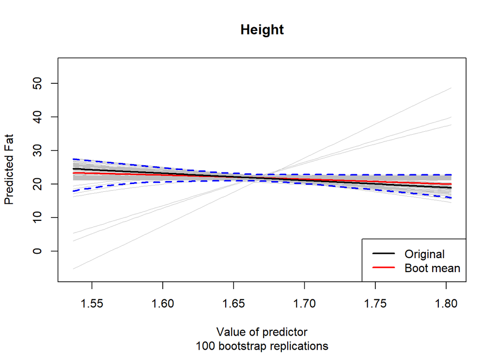

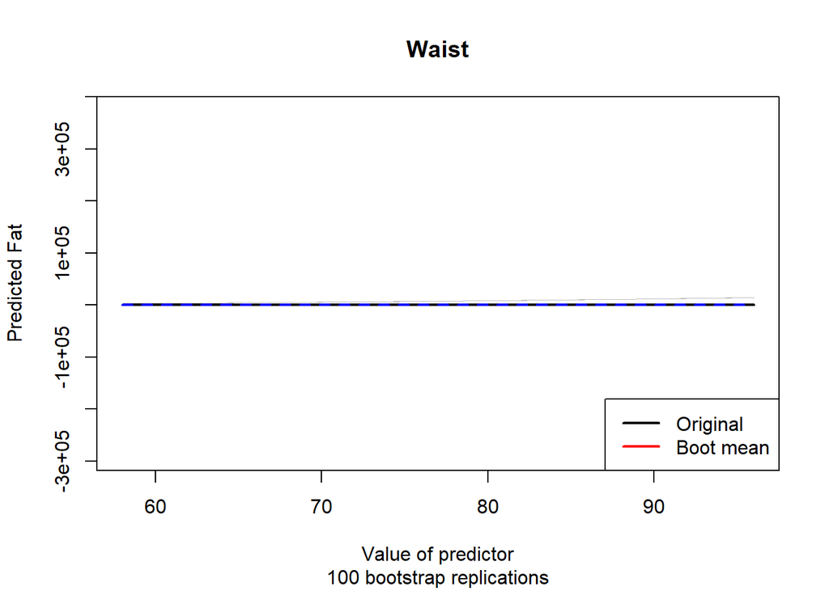

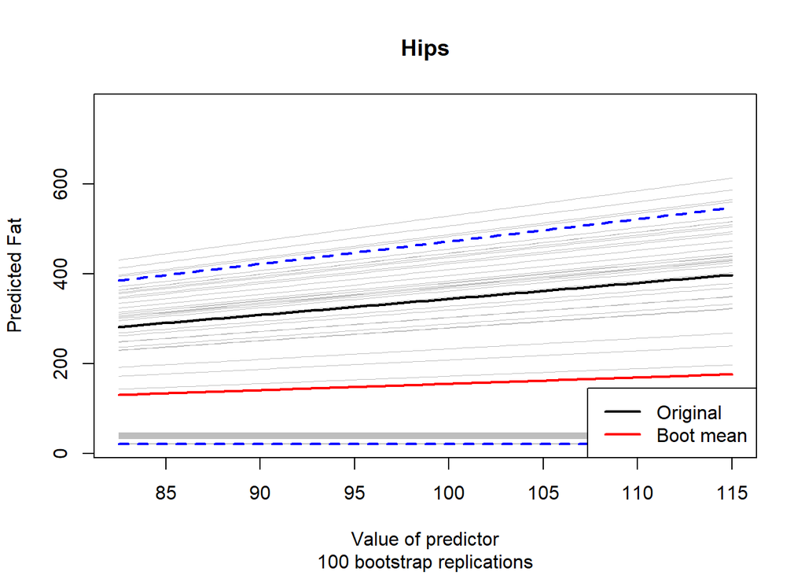

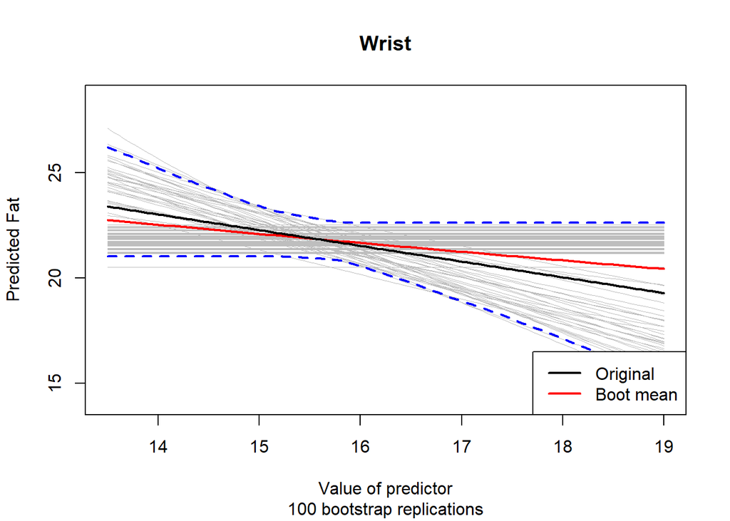

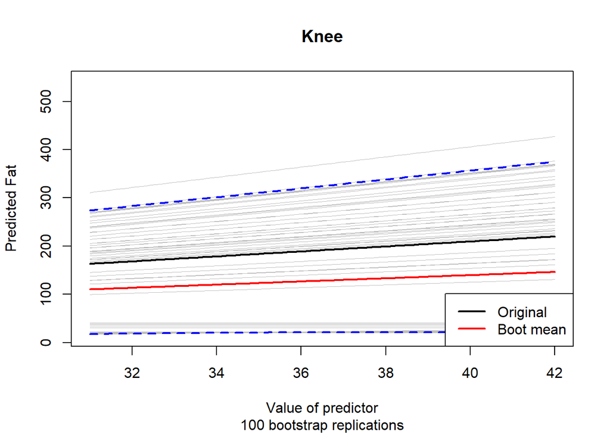

```r
for(predictor in sel.predictors.M4.fp1){
  plot(pred_range[,predictor], p.M4.fp1[[predictor]][,"value"], type="l", lwd=2, ylim=range(spagh[[predictor]]),
       ylab="Predicted Fat", xlab="Value of predictor")
  for(b in 1:100) lines(pred_range[,predictor], spagh[[predictor]][,b], lwd=0.01, col="grey")
  lines(pred_range[,predictor], apply(spagh[[predictor]],1, mean), lwd=2, col="red")
  lines(pred_range[,predictor], p.M4.fp1[[predictor]][,"value"], lwd=2, col="black")
  lines(pred_range[,predictor], apply(spagh[[predictor]],1, function(X) quantile(X, 0.025)), lwd=2, lty=2, col="blue")
  lines(pred_range[,predictor], apply(spagh[[predictor]],1, function(X) quantile(X, 0.975)), lwd=2, lty=2, col="blue")
  title(main=predictor, sub="100 bootstrap replications")
  legend("bottomright", lwd=c(2,2), col=c("black","red"), legend=c("Original","Boot mean"))
}
```

## 2.4 Recalibration

### 2.4.1 Recalibrated coefficients

Recalibrate the model with the estimated calibration slope.

```r
# since the model only has linear effects, first refit the model with lm for simplicity
M4.refit <- lm(data=women_AS, as.formula(paste("Fat~",paste(sel.predictors.M4.fp1,collapse="+"))), x=T, y=T)
M4.recalib <- M4.refit

# first multiply slopes with calibration slope (=shrinkage factor)

M4.recalib$coefficients[-1] <- M4.refit$coefficients[-1] * mean_calib_slope

# second, adjust intercept such that the mean prediction is equal to the mean y of the training set

M4.recalib$coefficients[1] <- M4.refit$coefficients[1] - mean(predict(M4.recalib, newdata=women_AS[,sel.predictors.M4.fp1]), na.rm=T) + mean(M4.refit$y, na.rm=T)
```

### 2.4.2 Check the coefficients

```r
cbind(M4.recalib$coefficients, M4.refit$coefficients)
```

```
                   [,1]        [,2]
(Intercept)  -9.2681341 -11.7810933
Height      -19.5755378 -21.1595627
Waist         0.3667543   0.3964315
Hips          0.3299306   0.3566281
Wrist        -0.6915564  -0.7475162
Knee          0.4771648   0.5157763
```

### 2.4.3 Check the mean prediction against the mean Fat value of training set

```r
cat("Mean prediction:\n")
```

```
Mean prediction:
```

```r
mean(predict(M4.recalib, women_AS[,sel.predictors.M4.fp1]), na.rm=T)
```

```
[1] 21.78727
```

```r
cat("Mean of Fat in training set:\n")
```

```
Mean of Fat in training set:
```

```r
mean(M4.refit$y)
```

```
[1] 21.78727
```

# 3 External validation

## 3.1 Apply the fitted, recalibrated model to men data set

```r
men2 <- men |>
  mutate(Wrist = wrist)

pred_ext <- predict(M4.recalib, newdata=men2)

eval_men <- data.frame(men2, Prediction=pred_ext)
```

## 3.2 Performance measures at external validation

### 3.2.1 Root mean squared prediction error

```r
rmspe_ext <- sqrt(mean((men2$Fat - pred_ext)^2))
rmspe_ext
```

```
[1] 10.62492
```

### 3.2.2 R-squared

```r
Rsqu_ext <- 1 - mean((men2$Fat - pred_ext)^2)/var(men2$Fat)
Rsqu_ext
```

```
[1] -0.6070878
```

### 3.2.3 Calibration

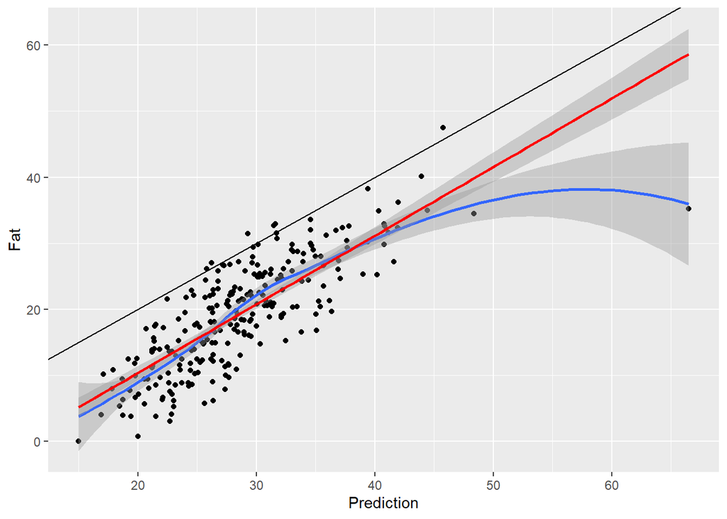

```r
library(ggplot2)
ggplot(eval_men, aes(Prediction, Fat)) + geom_point() + geom_smooth() + geom_smooth(method="lm", col="red") + geom_abline(intercept=0, slope=1)
```

#### 3.2.3.1 Calibration slope

```r
calib_slope_ext <- coef(lm(data=eval_men, Fat~Prediction))[2]
calib_slope_ext
```

```
Prediction
  1.040017
```

#### 3.2.3.2 Calibration intercept

```r
calib_inter_ext <- coef(lm(data=eval_men, Fat~offset(Prediction)))[1]
calib_inter_ext
```

```
(Intercept)
  -9.331727
```

### 3.2.4 Residual plots

#### 3.2.4.1 Local bias

Plot the residuals vs. the predictions.

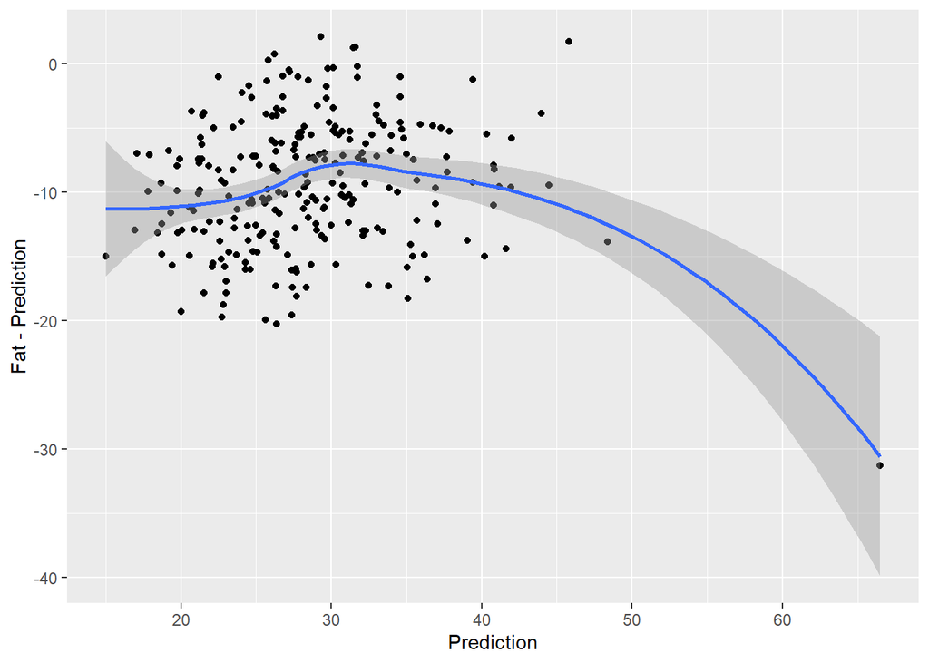

```r
ggplot(eval_men, aes(x=Prediction, y=Fat-Prediction)) + geom_point() + geom_smooth()
```

#### 3.2.4.2 Heteroskedasticity

Plot the square root of absolute residuals vs. predictions.

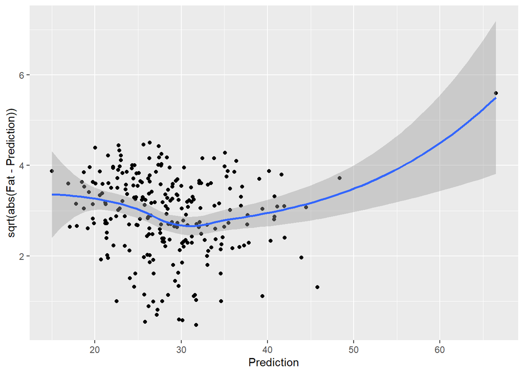

```r
ggplot(eval_men, aes(x=Prediction, y=sqrt(abs(Fat-Prediction)))) + geom_point() + geom_smooth()
```

#### 3.2.4.3 Residual nonlinear association with predictors

Plot residuals vs. predictors.

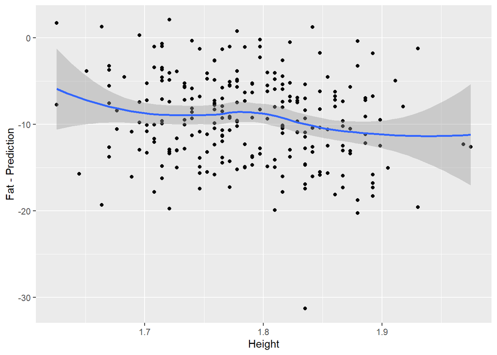

```r
ggplot(eval_men, aes(x=Height, y=Fat-Prediction)) + geom_point() + geom_smooth()
```

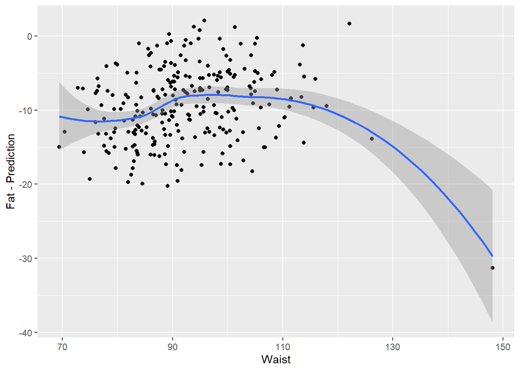

```r
ggplot(eval_men, aes(x=Waist, y=Fat-Prediction)) + geom_point() + geom_smooth()
```

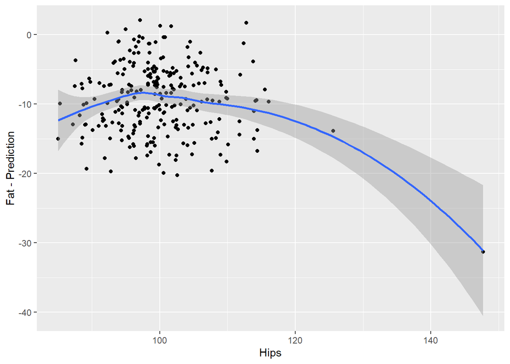

```r
ggplot(eval_men, aes(x=Hips, y=Fat-Prediction)) + geom_point() + geom_smooth()
```

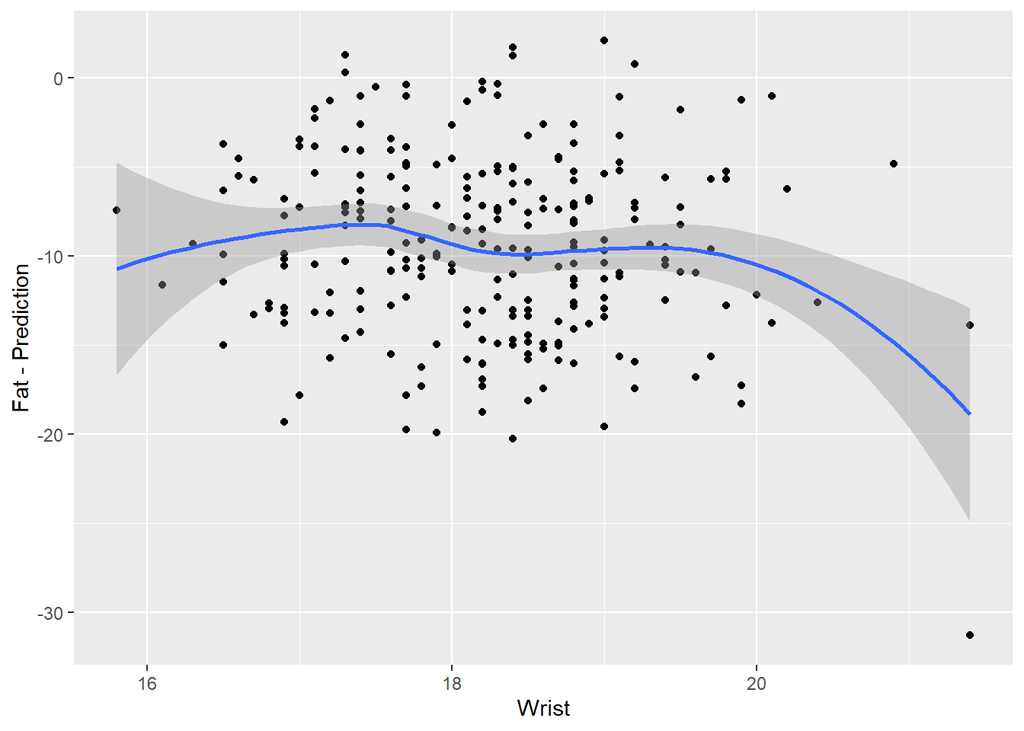

```r
ggplot(eval_men, aes(x=Wrist, y=Fat-Prediction)) + geom_point() + geom_smooth()
```

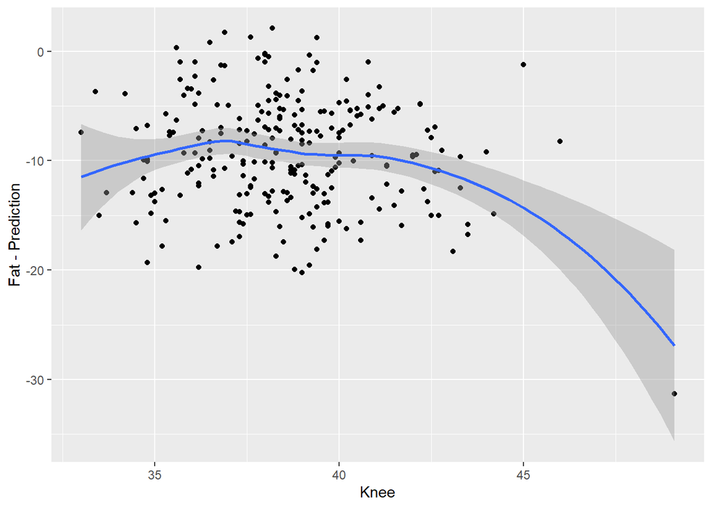

```r
ggplot(eval_men, aes(x=Knee, y=Fat-Prediction)) + geom_point() + geom_smooth()
```

#### 3.2.4.4 Residual association with non-predictors

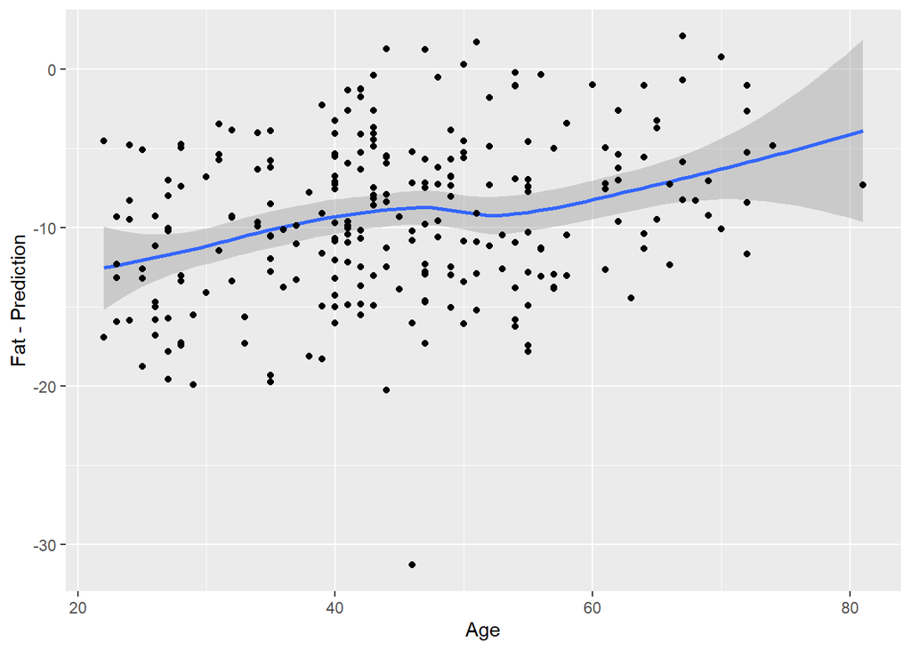

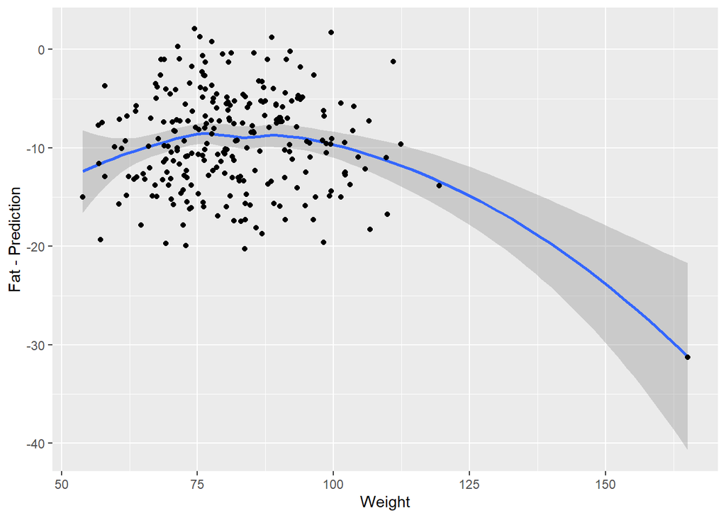

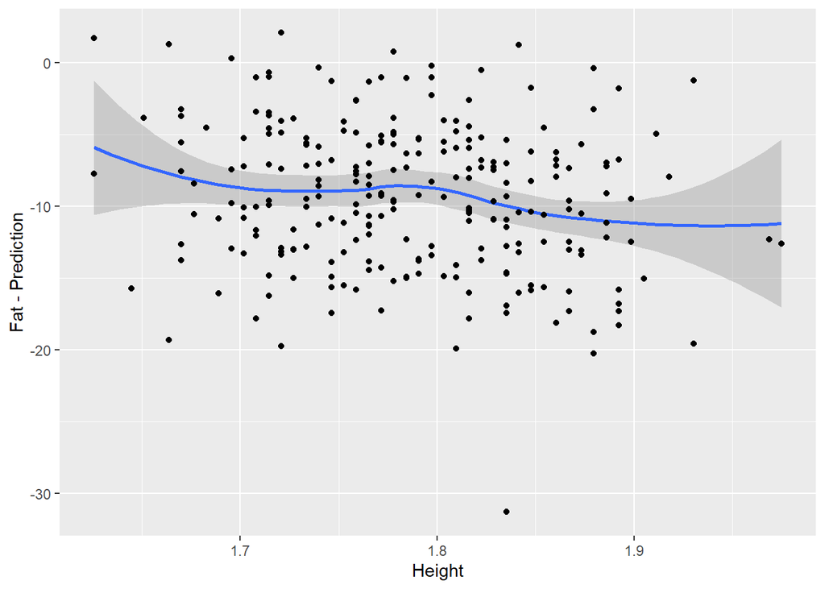

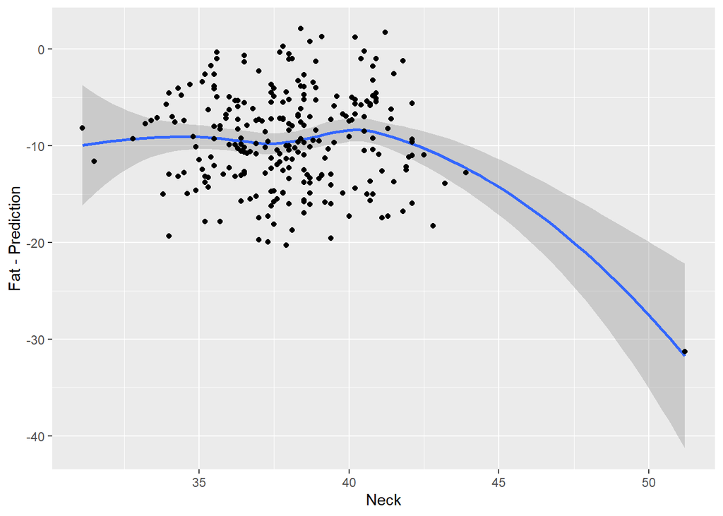

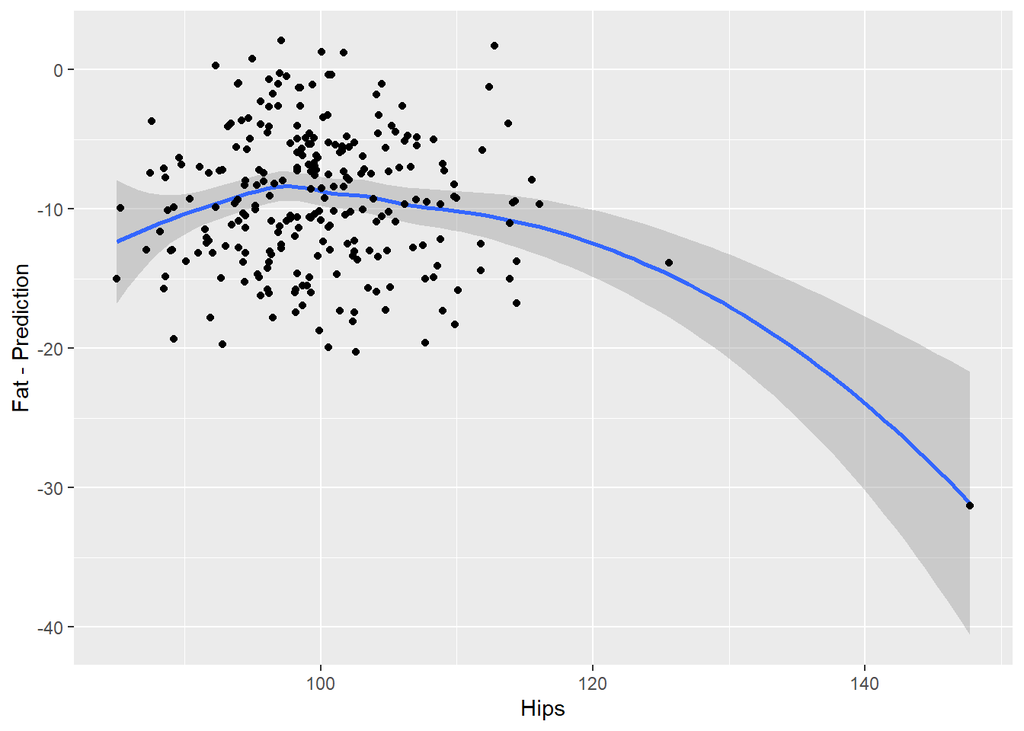

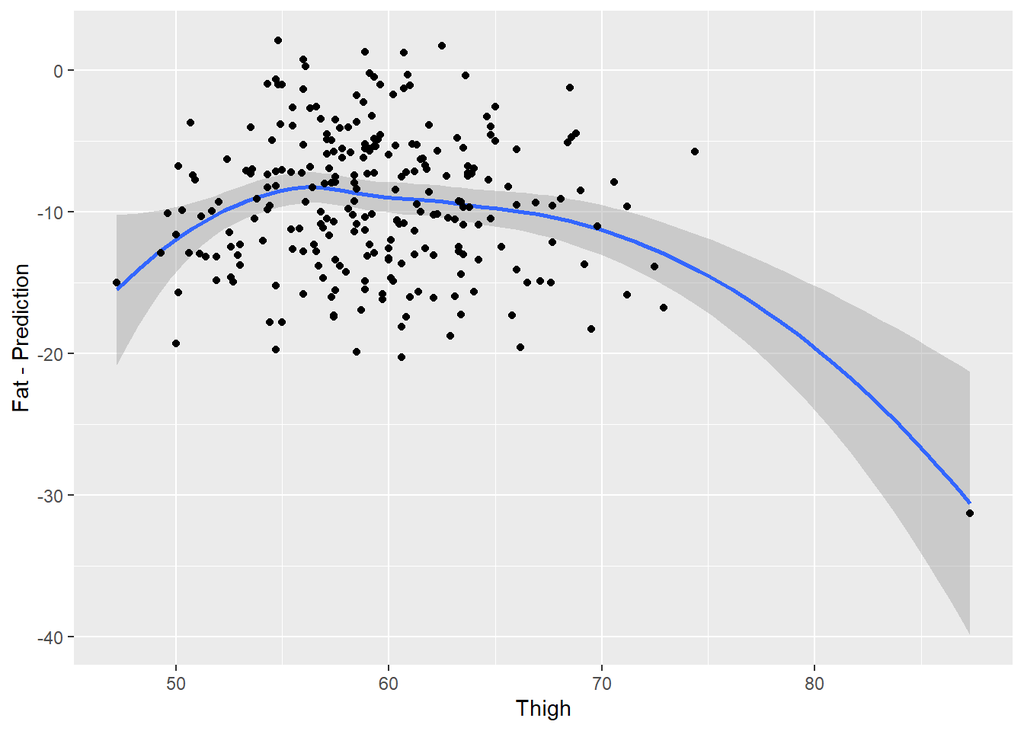

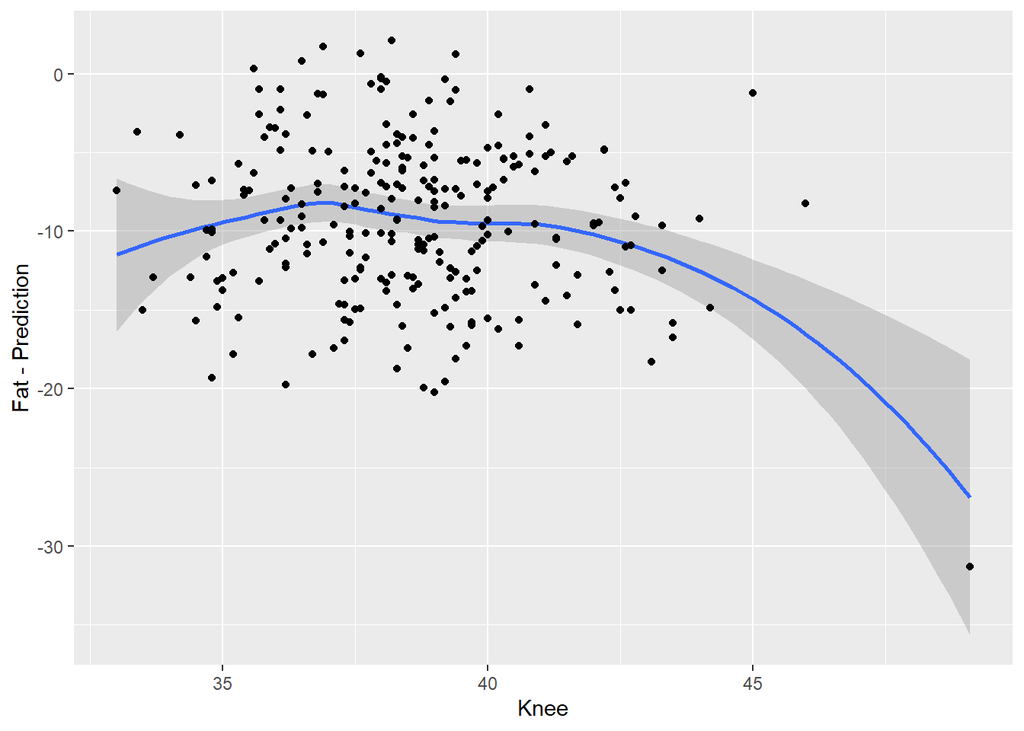

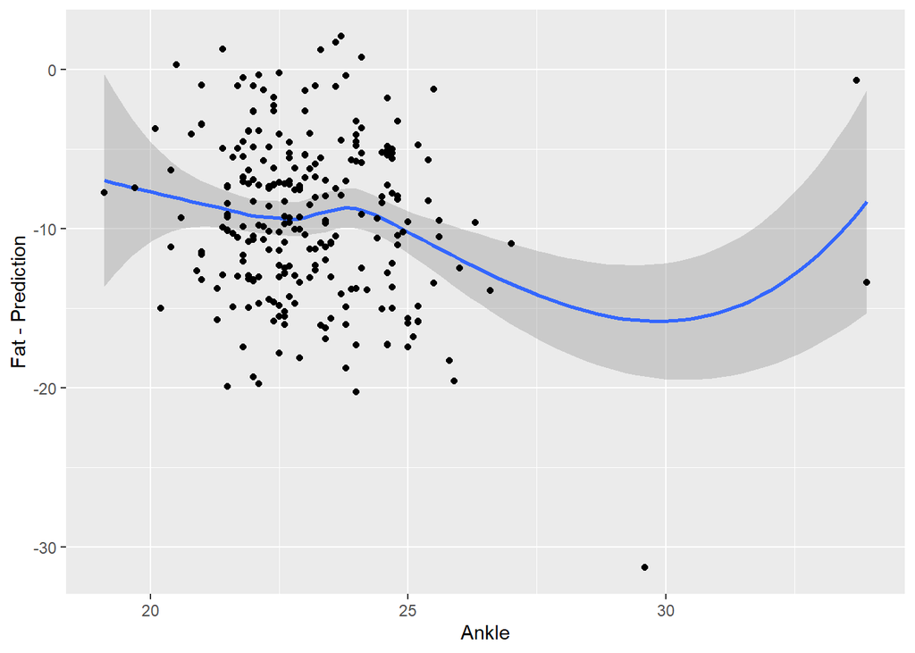

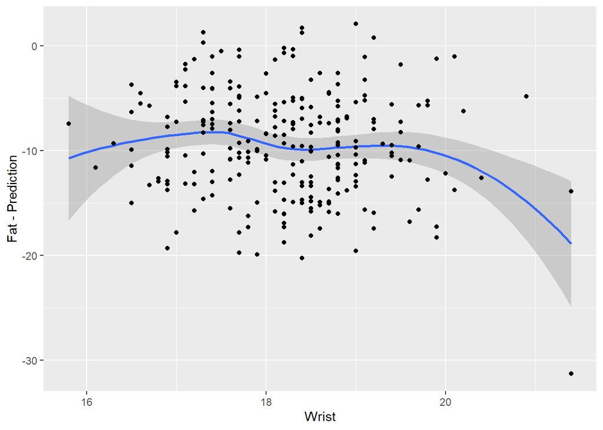

```r
nonpredictors <- colnames(eval_men)[is.na(match(candidate_predictors, sel.predictors.M4.fp1))]
nonpredictors <- nonpredictors[is.na(match(nonpredictors, c("case", "Fat", "density", "wrist", "Prediction")))]

for(p in nonpredictors){
  pl <- ggplot(eval_men, aes(eval_men[,p], Fat-Prediction)) + geom_smooth() + geom_point() + xlab(p)
  print(pl)
}
```